# Supervised Learning - Foundations Project: ReCell

## Problem Statement

### Business Context

Buying and selling used phones and tablets used to be something that happened on a handful of online marketplace sites. But the used and refurbished device market has grown considerably over the past decade, and a new IDC (International Data Corporation) forecast predicts that the used phone market would be worth \$52.7bn by 2023 with a compound annual growth rate (CAGR) of 13.6% from 2018 to 2023. This growth can be attributed to an uptick in demand for used phones and tablets that offer considerable savings compared with new models.

Refurbished and used devices continue to provide cost-effective alternatives to both consumers and businesses that are looking to save money when purchasing one. There are plenty of other benefits associated with the used device market. Used and refurbished devices can be sold with warranties and can also be insured with proof of purchase. Third-party vendors/platforms, such as Verizon, Amazon, etc., provide attractive offers to customers for refurbished devices. Maximizing the longevity of devices through second-hand trade also reduces their environmental impact and helps in recycling and reducing waste. The impact of the COVID-19 outbreak may further boost this segment as consumers cut back on discretionary spending and buy phones and tablets only for immediate needs.

### Objective

The rising potential of this comparatively under-the-radar market fuels the need for an ML-based solution to develop a dynamic pricing strategy for used and refurbished devices. ReCell, a startup aiming to tap the potential in this market, has hired you as a data scientist. They want you to analyze the data provided and build a linear regression model to predict the price of a used phone/tablet and identify factors that significantly influence it.

### Data Description

The data contains the different attributes of used/refurbished phones and tablets. The data was collected in the year 2021. The detailed data dictionary is given below.

- brand_name: Name of manufacturing brand
- os: OS on which the device runs
- screen_size: Size of the screen in cm
- 4g: Whether 4G is available or not
- 5g: Whether 5G is available or not
- main_camera_mp: Resolution of the rear camera in megapixels
- selfie_camera_mp: Resolution of the front camera in megapixels
- int_memory: Amount of internal memory (ROM) in GB
- ram: Amount of RAM in GB
- battery: Energy capacity of the device battery in mAh
- weight: Weight of the device in grams
- release_year: Year when the device model was released
- days_used: Number of days the used/refurbished device has been used
- normalized_new_price: Normalized price of a new device of the same model in euros
- normalized_used_price: Normalized price of the used/refurbished device in euros

## Importing necessary libraries

```python
import pandas as pd
import numpy as np
import matplotlib.pyplot as plt
import seaborn as sns
%matplotlib inline

import scipy.stats as stats

# For randomized data splitting
from sklearn.model_selection import train_test_split

# To build linear regression_model
import statsmodels.api as sm

# To check model performance
from sklearn.metrics import mean_absolute_error, mean_squared_error
```

## Loading the dataset

```python
df = pd.read_csv('used_device_data.csv')
```

## Data Overview

- Observations
- Sanity checks

```python
df.head(10) # Displays the first 10 rows of the dataset
```

|  | brand_name | os | screen_size | 4g | 5g | main_camera_mp | selfie_camera_mp | int_memory | ram | battery | weight | release_year | days_used | normalized_used_price | normalized_new_price |
| --- | --- | --- | --- | --- | --- | --- | --- | --- | --- | --- | --- | --- | --- | --- | --- |
| 0 | Honor | Android | 14.50 | yes | no | 13.0 | 5.0 | 64.0 | 3.0 | 3020.0 | 146.0 | 2020 | 127 | 4.307572 | 4.715100 |
| 1 | Honor | Android | 17.30 | yes | yes | 13.0 | 16.0 | 128.0 | 8.0 | 4300.0 | 213.0 | 2020 | 325 | 5.162097 | 5.519018 |
| 2 | Honor | Android | 16.69 | yes | yes | 13.0 | 8.0 | 128.0 | 8.0 | 4200.0 | 213.0 | 2020 | 162 | 5.111084 | 5.884631 |
| 3 | Honor | Android | 25.50 | yes | yes | 13.0 | 8.0 | 64.0 | 6.0 | 7250.0 | 480.0 | 2020 | 345 | 5.135387 | 5.630961 |
| 4 | Honor | Android | 15.32 | yes | no | 13.0 | 8.0 | 64.0 | 3.0 | 5000.0 | 185.0 | 2020 | 293 | 4.389995 | 4.947837 |
| 5 | Honor | Android | 16.23 | yes | no | 13.0 | 8.0 | 64.0 | 4.0 | 4000.0 | 176.0 | 2020 | 223 | 4.413889 | 5.060694 |
| 6 | Honor | Android | 13.84 | yes | no | 8.0 | 5.0 | 32.0 | 2.0 | 3020.0 | 144.0 | 2020 | 234 | 3.878259 | 4.518958 |
| 7 | Honor | Android | 15.77 | yes | no | 13.0 | 8.0 | 64.0 | 4.0 | 3400.0 | 164.0 | 2020 | 219 | 4.729421 | 5.188726 |
| 8 | Honor | Android | 15.32 | yes | no | 13.0 | 16.0 | 128.0 | 6.0 | 4000.0 | 165.0 | 2020 | 161 | 4.886054 | 5.299916 |
| 9 | Honor | Android | 16.23 | yes | no | 13.0 | 8.0 | 128.0 | 6.0 | 4000.0 | 176.0 | 2020 | 327 | 4.773224 | 5.073610 |

```python
df.shape # Displays number of rows and columns in the dataset respectively
```

```
(3454, 15)
```

```python
df.info() # Displays the datatypes of the dataset
```

```
<class 'pandas.core.frame.DataFrame'>
RangeIndex: 3454 entries, 0 to 3453
Data columns (total 15 columns):
 #   Column                 Non-Null Count  Dtype
---  ------                 --------------  -----
 0   brand_name             3454 non-null   object
 1   os                     3454 non-null   object
 2   screen_size            3454 non-null   float64
 3   4g                     3454 non-null   object
 4   5g                     3454 non-null   object
 5   main_camera_mp         3275 non-null   float64
 6   selfie_camera_mp       3452 non-null   float64
 7   int_memory             3450 non-null   float64
 8   ram                    3450 non-null   float64
 9   battery                3448 non-null   float64
 10  weight                 3447 non-null   float64
 11  release_year           3454 non-null   int64
 12  days_used              3454 non-null   int64
 13  normalized_used_price  3454 non-null   float64
 14  normalized_new_price   3454 non-null   float64
dtypes: float64(9), int64(2), object(4)
memory usage: 404.9+ KB
```

### The Dataset consists of 3454 Rows and 15 Columns

```python
df.describe() # Displays Statistical Summary of the Data
```

|  | screen_size | main_camera_mp | selfie_camera_mp | int_memory | ram | battery | weight | release_year | days_used | normalized_used_price | normalized_new_price |
| --- | --- | --- | --- | --- | --- | --- | --- | --- | --- | --- | --- |
| count | 3454.000000 | 3275.000000 | 3452.000000 | 3450.000000 | 3450.000000 | 3448.000000 | 3447.000000 | 3454.000000 | 3454.000000 | 3454.000000 | 3454.000000 |
| mean | 13.713115 | 9.460208 | 6.554229 | 54.573099 | 4.036122 | 3133.402697 | 182.751871 | 2015.965258 | 674.869716 | 4.364712 | 5.233107 |
| std | 3.805280 | 4.815461 | 6.970372 | 84.972371 | 1.365105 | 1299.682844 | 88.413228 | 2.298455 | 248.580166 | 0.588914 | 0.683637 |
| min | 5.080000 | 0.080000 | 0.000000 | 0.010000 | 0.020000 | 500.000000 | 69.000000 | 2013.000000 | 91.000000 | 1.536867 | 2.901422 |
| 25% | 12.700000 | 5.000000 | 2.000000 | 16.000000 | 4.000000 | 2100.000000 | 142.000000 | 2014.000000 | 533.500000 | 4.033931 | 4.790342 |
| 50% | 12.830000 | 8.000000 | 5.000000 | 32.000000 | 4.000000 | 3000.000000 | 160.000000 | 2015.500000 | 690.500000 | 4.405133 | 5.245892 |
| 75% | 15.340000 | 13.000000 | 8.000000 | 64.000000 | 4.000000 | 4000.000000 | 185.000000 | 2018.000000 | 868.750000 | 4.755700 | 5.673718 |
| max | 30.710000 | 48.000000 | 32.000000 | 1024.000000 | 12.000000 | 9720.000000 | 855.000000 | 2020.000000 | 1094.000000 | 6.619433 | 7.847841 |

### Not all the columns have a count of 3454 (matching the total number of rows)

### Therefore we should see if there are any missing values

```python
df.isnull().sum() # Shows number of null entries
```

```
brand_name                 0
os                         0
screen_size                0
4g                         0
5g                         0
main_camera_mp           179
selfie_camera_mp           2
int_memory                 4
ram                        4
battery                    6
weight                     7
release_year               0
days_used                  0
normalized_used_price      0
normalized_new_price       0
dtype: int64
```

```python
# Displaying the null values of each column

df[df['weight'].isna()]
df[df['selfie_camera_mp'].isna()]
df[df['int_memory'].isna()]
df[df['main_camera_mp'].isna()]
df[df['ram'].isna()]
df[df['battery'].isna()]
```

|  | brand_name | os | screen_size | 4g | 5g | main_camera_mp | selfie_camera_mp | int_memory | ram | battery | weight | release_year | days_used | normalized_used_price | normalized_new_price |
| --- | --- | --- | --- | --- | --- | --- | --- | --- | --- | --- | --- | --- | --- | --- | --- |
| 1829 | Meizu | Android | 12.83 | yes | no | 13.0 | 5.0 | 16.00 | 4.00 | NaN | 145.0 | 2014 | 986 | 4.177919 | 4.863604 |
| 1831 | Meizu | Android | 12.83 | yes | no | 20.7 | 5.0 | 16.00 | 4.00 | NaN | 158.0 | 2014 | 1043 | 4.878855 | 5.990639 |
| 1832 | Meizu | Android | 13.61 | yes | no | 20.7 | 2.0 | 16.00 | 4.00 | NaN | 147.0 | 2014 | 1007 | 4.742320 | 5.826118 |
| 1962 | Microsoft | Windows | 25.55 | no | no | 5.0 | 3.5 | 32.00 | 4.00 | NaN | 675.9 | 2013 | 931 | 5.230574 | 5.802753 |
| 2058 | Nokia | Others | 5.18 | no | no | 0.3 | 0.0 | 0.06 | 0.02 | NaN | 81.0 | 2016 | 815 | 2.718660 | 3.374511 |
| 2059 | Nokia | Others | 5.18 | no | no | 0.3 | 0.0 | 0.06 | NaN | NaN | 82.6 | 2016 | 1023 | 2.765060 | 3.657905 |

```python
df[df['brand_name'] == 'Nokia'].head(20) # Displays the first 50 rows of phone's of Nokia brand
```

|  | brand_name | os | screen_size | 4g | 5g | main_camera_mp | selfie_camera_mp | int_memory | ram | battery | weight | release_year | days_used | normalized_used_price | normalized_new_price |
| --- | --- | --- | --- | --- | --- | --- | --- | --- | --- | --- | --- | --- | --- | --- | --- |
| 110 | Nokia | Android | 16.56 | yes | no | 0.3 | 8.0 | 64.00 | 3.00 | 4000.0 | 200.0 | 2020 | 310 | 4.186012 | 5.004885 |
| 111 | Nokia | Android | 13.84 | yes | no | 0.3 | 5.0 | 16.00 | 2.00 | 3000.0 | 180.0 | 2020 | 193 | 3.616309 | 4.100161 |
| 112 | Nokia | Android | 13.84 | yes | no | 0.3 | 5.0 | 16.00 | 2.00 | 3000.0 | 180.0 | 2020 | 356 | 4.055430 | 4.591984 |
| 113 | Nokia | Others | 5.18 | no | no | 0.3 | 0.0 | 0.10 | 0.03 | 1020.0 | 90.5 | 2020 | 272 | 2.910174 | 3.399863 |
| 114 | Nokia | Others | 5.18 | no | no | 0.3 | 0.0 | 0.06 | NaN | 1020.0 | 91.3 | 2020 | 288 | 2.729159 | 2.911263 |
| 115 | Nokia | Android | 17.30 | yes | yes | 0.3 | 24.0 | 64.00 | 6.00 | 4500.0 | 220.0 | 2020 | 284 | 5.314043 | 6.216846 |
| 116 | Nokia | Others | 5.18 | no | no | 0.3 | 0.0 | 0.06 | 0.02 | 1200.0 | 88.2 | 2020 | 266 | 3.370738 | 3.699077 |
| 117 | Nokia | Others | 5.18 | yes | no | 0.3 | 0.0 | NaN | 0.02 | 1200.0 | 86.5 | 2019 | 234 | 2.721295 | 3.688379 |
| 329 | Nokia | Android | 16.56 | yes | no | 0.3 | 8.0 | 64.00 | 3.00 | 4000.0 | 200.0 | 2020 | 296 | 4.160756 | 4.996469 |
| 330 | Nokia | Android | 13.84 | yes | no | 0.3 | 5.0 | 16.00 | 2.00 | 3000.0 | 180.0 | 2020 | 293 | 3.690628 | 4.087488 |
| 331 | Nokia | Android | 13.84 | yes | no | 0.3 | 5.0 | 16.00 | 2.00 | 3000.0 | 180.0 | 2020 | 260 | 3.988243 | 4.617889 |
| 332 | Nokia | Others | 5.18 | no | no | 0.3 | 0.0 | 0.06 | 0.03 | 1020.0 | 90.5 | 2020 | 322 | 2.519308 | 3.386422 |
| 333 | Nokia | Others | 5.18 | no | no | 0.3 | 0.0 | 0.10 | 0.03 | 1020.0 | 91.3 | 2020 | 148 | 2.564949 | 3.011606 |
| 334 | Nokia | Android | 17.30 | yes | yes | 0.3 | 24.0 | 64.00 | 6.00 | 4500.0 | 220.0 | 2020 | 127 | 4.602667 | 6.214388 |
| 335 | Nokia | Others | 5.18 | no | no | 0.3 | 0.0 | 0.10 | NaN | 1200.0 | 88.2 | 2020 | 327 | 3.062924 | 3.689129 |
| 336 | Nokia | Others | 5.18 | yes | no | 0.3 | 0.0 | 0.10 | 0.03 | 1200.0 | 86.5 | 2019 | 414 | 2.789323 | 3.684620 |
| 2030 | Nokia | Android | 16.23 | yes | no | 5.0 | 16.0 | 128.00 | 4.00 | 3500.0 | 180.0 | 2019 | 188 | 4.620551 | 5.671122 |
| 2031 | Nokia | Android | 15.21 | yes | no | 5.0 | 20.0 | 128.00 | 4.00 | 3320.0 | 172.0 | 2019 | 294 | 5.192957 | 6.429235 |
| 2032 | Nokia | Android | 14.50 | yes | no | 5.0 | 8.0 | 32.00 | 4.00 | 3000.0 | 161.0 | 2019 | 492 | 4.251776 | 5.004215 |
| 2033 | Nokia | Android | 15.90 | yes | no | 13.0 | 5.0 | 32.00 | 4.00 | 4000.0 | 181.0 | 2019 | 317 | 4.579339 | 4.861284 |

### There are plenty of null values, however they are consistent with the brand name, year and operating system

### As there is no specific column for the phone model, we can assume that phones with the same brand, year and OS are of the same model and that the null values are consistent with the model and not random. Due to this we can assume that phones with no mentioned Main Camera MP (which has the most null values) either do not have a back camera or the megapixels for those models were not listed

```python
df.duplicated().sum() # Checking For Duplicate values
```

```
0
```

### Section Summary:

- There are 3454 rows and 15 columns
- All the datatypes for each column seem appropriate and nothing needs to be converted
- There are some null values, particularly significant for back camera MP
- From filtering the dataset, we found the null values to be consistent with the phone's brand, OS and year
- This indicates consistency between null values for specific phone models
- To handle those, we must know if the specific models have/don't have a back camera
- If they don't have a back camera, we can ignore the null values
- If they have a back camera we can either look up the phone information for those models or if the data isn't available we can substitute the null value with the mean back camera megapixel value
- There are no duplicate values
- Refer to df.describe() for a direct statistical summary

## Exploratory Data Analysis (EDA)

- EDA is an important part of any project involving data.
- It is important to investigate and understand the data better before building a model with it.
- A few questions have been mentioned below which will help you approach the analysis in the right manner and generate insights from the data.
- A thorough analysis of the data, in addition to the questions mentioned below, should be done.

**Questions**:

1. What does the distribution of normalized used device prices look like?
2. What percentage of the used device market is dominated by Android devices?
3. The amount of RAM is important for the smooth functioning of a device. How does the amount of RAM vary with the brand?
4. A large battery often increases a device's weight, making it feel uncomfortable in the hands. How does the weight vary for phones and tablets offering large batteries (more than 4500 mAh)?
5. Bigger screens are desirable for entertainment purposes as they offer a better viewing experience. How many phones and tablets are available across different brands with a screen size larger than 6 inches?
6. A lot of devices nowadays offer great selfie cameras, allowing us to capture our favorite moments with loved ones. What is the distribution of devices offering greater than 8MP selfie cameras across brands?
7. Which attributes are highly correlated with the normalized price of a used device?

### [1] Normalized Used Price Distribution

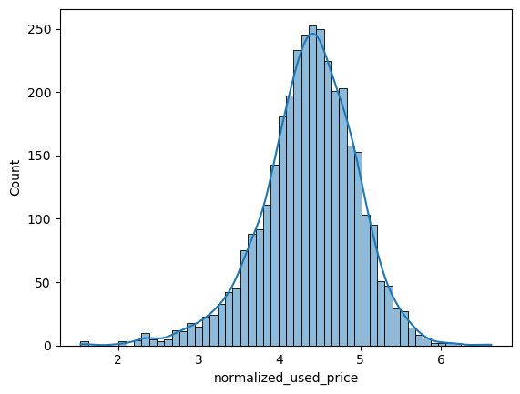

```python
# Generating a histogram with a KDE line

sns.histplot(data=df, x='normalized_used_price', kde=True);
```

#### From the graph, we can see that most of the phones are priced between 4-5 Euros (Normalized)

### [2] Phone Operating System Distribution

```
93.05153445280834
```

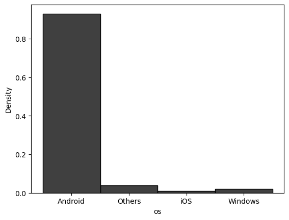

```python
sns.histplot(data = df, x='os', stat='density', color = 'black'); # Create a histogram measuring the density of each OS

print( df[df['os']=='Android'].shape[0] / df.shape[0] * 100) # Print the percentage of phones in the shop that use Android OS
```

### [3] RAM Distribution Categorized by Brand

- Making 2 plots, the first looking at the mean RAM for each brand, however since there are significant outliers, we will also be making a plot using the median RAM for each brand

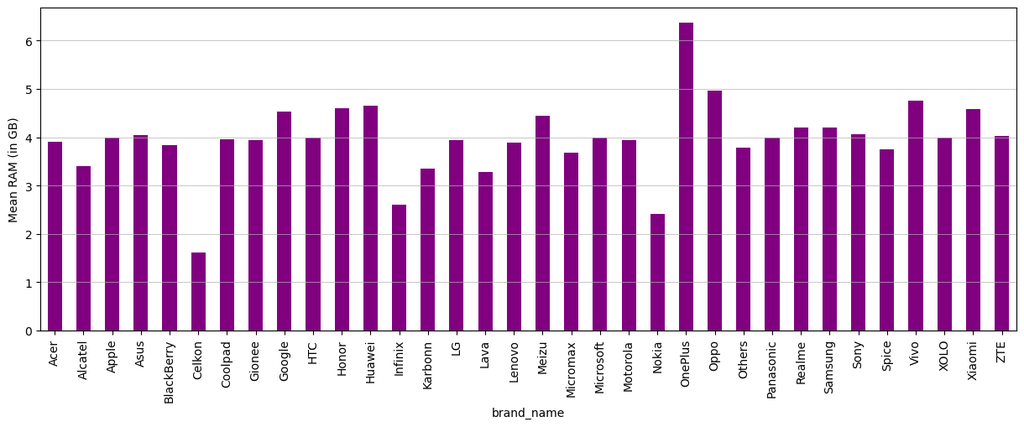

```python
# Creating a Barplot of Mean RAM vs. Brand Name

plt.figure(figsize=(15,5))
df.groupby('brand_name')['ram'].mean(numeric_only = True).plot.bar(color = 'purple')
plt.grid(axis='y', linewidth=0.5)
plt.ylabel('Mean RAM (in GB)');
```

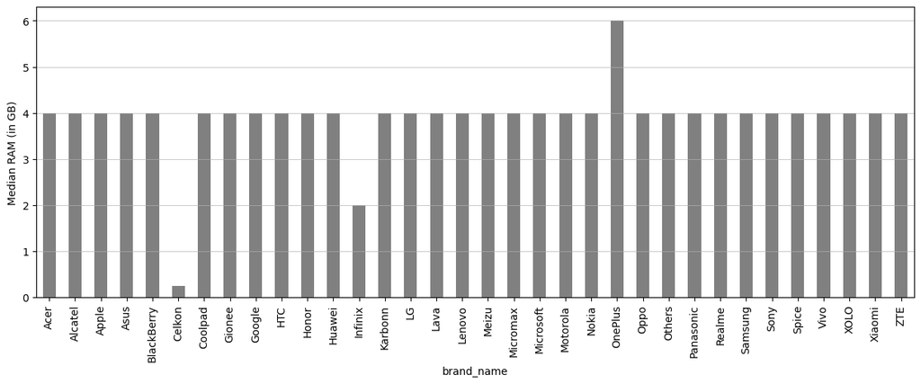

```python
# Creating a Barplot of Median RAM vs. Brand Name

plt.figure(figsize=(15,5))
df.groupby('brand_name')['ram'].median(numeric_only = True).plot.bar(color = 'gray')
plt.grid(axis='y', linewidth=0.5)
plt.ylabel('Median RAM (in GB)');
```

### [4] How battery energy capacity and weight are correlated

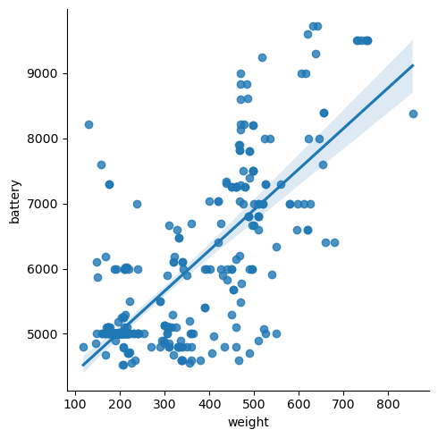

```python
df.head()
df_battery = df[df['battery']>4500]
sns.lmplot(data = df_battery , x = 'weight' , y = 'battery');
```

- While the data is quite scattered when looking at the 2 relationships, we can see the general trendline shows a positive correlation between battery capacity and weight

### [5] Number of Phones/Tablets from each brand with a screen size greater than 6 inches (15.24 cm)

```
149
```

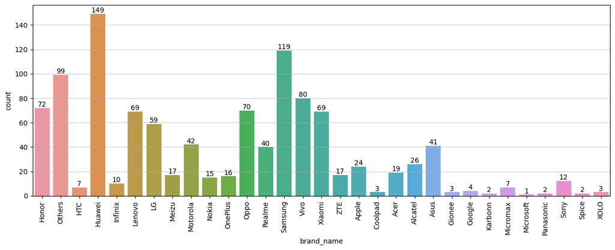

```python
df_ss = df[df['screen_size'] > 15.24] # Filters to display only rows where the screen size is greater than 6 inches (15.24cm)

# Creating a countplot of number of phones/tablets for each brand using the filtered dataset
plt.figure(figsize=(15,5))
fig1 = sns.countplot(data=df_ss, x='brand_name');
plt.grid(axis='y', linewidth=0.5)
plt.xticks(rotation=90);
fig1.bar_label(fig1.containers[0], label_type='edge'); # Add data labels

df_ss[df_ss['brand_name']=='Huawei'].shape[0] # Displays the exact count of phones and tablets from Huawei with a screensize > 6in
```

- There are a total of 1099 devices with a screen size greater than 6 inches
- The brand with the most number of these devices is Huawei with 149 phones/tablets followed by Samsung with 119 devices

### [6] Number of Phones/Tablets from each brand with a front camera resolution of over 8 Megapixels

```
655
```

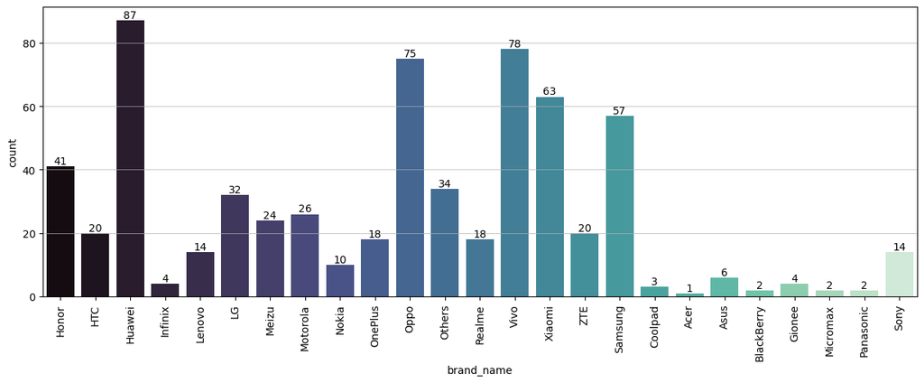

```python
# Filtering to display only rows where the front camera resolution is greater than 8 megapixels
df_selfie = df[df['selfie_camera_mp'] > 8]

# Creating a countplot of number of phones/tablets for each brand using the filtered dataset
plt.figure(figsize=(15,5))
fig2 = sns.countplot(data=df_selfie, x='brand_name', palette = 'mako');
plt.grid(axis='y', linewidth=0.5)
plt.xticks(rotation=90);
fig2.bar_label(fig2.containers[0], label_type='edge'); # Add data labels

df_selfie.shape[0] # Displays the exact count of phones and tablets with a front camera resolution of over 8 megapixels
```

- There are a total of 655 phones/tablets available with a front camera resolution of over 8 megapixels
- The brands with the largest number of available options in order include: 1) Huawei - 87 2) Vivo - 78 3) Oppo - 75 4) Xiaomi - 63 5) Samsung - 57

### [7] Which attributes are highly correlated with the used selling price

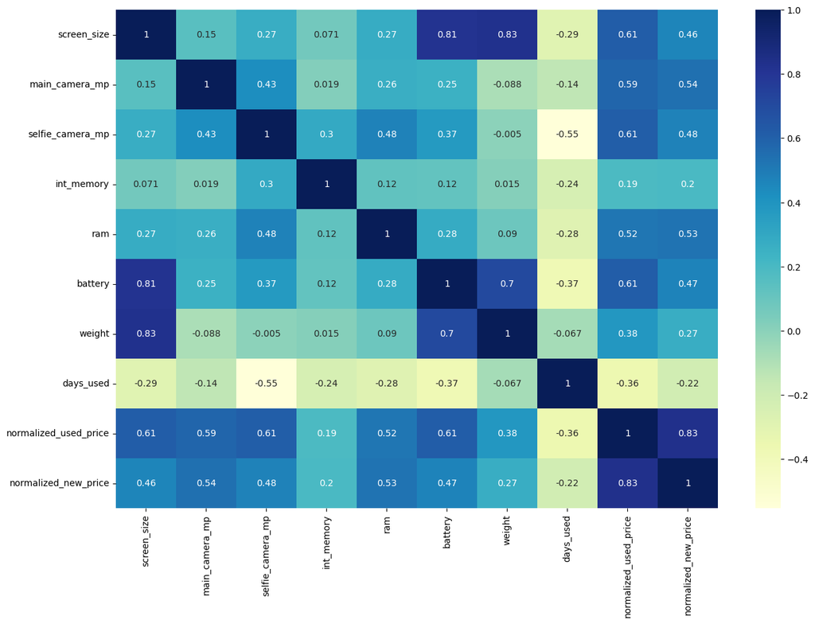

```python
plt.figure(figsize=(15,10))
sns.heatmap(data=df[['screen_size',
                     'main_camera_mp',
                     'selfie_camera_mp',
                     'int_memory','ram',
                     'battery',
                    'weight',
                    'days_used',
                    'normalized_used_price',
                    'normalized_new_price']].corr(), annot=True, cmap='YlGnBu');
```

- The attributes that are highly correlated with the used price are: 1) The price of the device when it was new 2) The screen size 3) The battery capacity 4) The resolution of the front and back cameras 5) The RAM
- Surprisingly the internal memory has minimal correlation with the price of the device (even less so than the weight)
- As expected, the number of days the device has been used has a negative correlation with the used selling price

## Data Preprocessing

- Missing value treatment
- Feature engineering (if needed)
- Outlier detection and treatment (if needed)
- Preparing data for modeling
- Any other preprocessing steps (if needed)

### Missing Value Treatment

```python
df.median(numeric_only=True) # Displays the median of the numeric values
```

```
screen_size                12.830000
main_camera_mp              8.000000
selfie_camera_mp            5.000000
int_memory                 32.000000
ram                         4.000000
battery                  3000.000000
weight                    160.000000
release_year             2015.500000
days_used                 690.500000
normalized_used_price       4.405133
normalized_new_price        5.245892
dtype: float64
```

- As the median values look reasonable to substitute the missing values with without cause much disturbance in the dataset while allowing for a complete analysis, we will substitute the null values with the median for each column

```python
# Filling null values with the median from each column
medianFiller = lambda x: x.fillna(x.median())
df_filled = df.select_dtypes(include=np.number).apply(medianFiller, axis=0)

# Creating a copy of this dataset
df_copy_filled = df.select_dtypes(include=np.number).apply(medianFiller, axis=0)

# Restoring non-numeric columns to the dataset
df_filled['brand_name']= df['brand_name']
df_filled['os']= df['os']
df_filled['4g']= df['4g']
df_filled['5g']= df['5g']
```

### Creating Dummy Variables

```python
# Creating Dummy Variables from all non-numeric features including Categorical and Boolean features

df_filled = pd.get_dummies(df_filled, columns=["4g"], drop_first=True)
df_filled = pd.get_dummies(df_filled, columns=["5g"], drop_first=True)
df_filled = pd.get_dummies(df_filled, columns=["brand_name"], drop_first=True)
df_filled = pd.get_dummies(df_filled, columns=["os"], drop_first=True)
df_filled
```

|  | screen_size | main_camera_mp | selfie_camera_mp | int_memory | ram | battery | weight | release_year | days_used | normalized_used_price | ... | brand_name_Samsung | brand_name_Sony | brand_name_Spice | brand_name_Vivo | brand_name_XOLO | brand_name_Xiaomi | brand_name_ZTE | os_Others | os_Windows | os_iOS |
| --- | --- | --- | --- | --- | --- | --- | --- | --- | --- | --- | --- | --- | --- | --- | --- | --- | --- | --- | --- | --- | --- |
| 0 | 14.50 | 13.0 | 5.0 | 64.0 | 3.0 | 3020.0 | 146.0 | 2020 | 127 | 4.307572 | ... | 0 | 0 | 0 | 0 | 0 | 0 | 0 | 0 | 0 | 0 |
| 1 | 17.30 | 13.0 | 16.0 | 128.0 | 8.0 | 4300.0 | 213.0 | 2020 | 325 | 5.162097 | ... | 0 | 0 | 0 | 0 | 0 | 0 | 0 | 0 | 0 | 0 |
| 2 | 16.69 | 13.0 | 8.0 | 128.0 | 8.0 | 4200.0 | 213.0 | 2020 | 162 | 5.111084 | ... | 0 | 0 | 0 | 0 | 0 | 0 | 0 | 0 | 0 | 0 |
| 3 | 25.50 | 13.0 | 8.0 | 64.0 | 6.0 | 7250.0 | 480.0 | 2020 | 345 | 5.135387 | ... | 0 | 0 | 0 | 0 | 0 | 0 | 0 | 0 | 0 | 0 |
| 4 | 15.32 | 13.0 | 8.0 | 64.0 | 3.0 | 5000.0 | 185.0 | 2020 | 293 | 4.389995 | ... | 0 | 0 | 0 | 0 | 0 | 0 | 0 | 0 | 0 | 0 |
| ... | ... | ... | ... | ... | ... | ... | ... | ... | ... | ... | ... | ... | ... | ... | ... | ... | ... | ... | ... | ... | ... |
| 3449 | 15.34 | 8.0 | 8.0 | 64.0 | 6.0 | 5000.0 | 190.0 | 2019 | 232 | 4.492337 | ... | 0 | 0 | 0 | 0 | 0 | 0 | 0 | 0 | 0 | 0 |
| 3450 | 15.24 | 13.0 | 8.0 | 128.0 | 8.0 | 4000.0 | 200.0 | 2018 | 541 | 5.037732 | ... | 0 | 0 | 0 | 0 | 0 | 0 | 0 | 0 | 0 | 0 |
| 3451 | 15.80 | 13.0 | 5.0 | 32.0 | 3.0 | 4000.0 | 165.0 | 2020 | 201 | 4.357350 | ... | 0 | 0 | 0 | 0 | 0 | 0 | 0 | 0 | 0 | 0 |
| 3452 | 15.80 | 13.0 | 5.0 | 32.0 | 2.0 | 4000.0 | 160.0 | 2020 | 149 | 4.349762 | ... | 0 | 0 | 0 | 0 | 0 | 0 | 0 | 0 | 0 | 0 |
| 3453 | 12.83 | 13.0 | 5.0 | 16.0 | 2.0 | 4000.0 | 168.0 | 2020 | 176 | 4.132122 | ... | 0 | 0 | 0 | 0 | 0 | 0 | 0 | 0 | 0 | 0 |

3454 rows × 49 columns

### Section Summary:

- The null values were identified and substituted with the median value for each column
- As there were several categorical variables in our dataset, we split them into dummy variables to be used in our regression modelling

## EDA

- It is a good idea to explore the data once again after manipulating it.

```python
# Checking to see if the dummy variables have been created properly, there will only be 2 unique values (1/0) in each dummy variable
df_filled.nunique()
```

```
screen_size               142
main_camera_mp             41
selfie_camera_mp           37
int_memory                 15
ram                        12
battery                   324
weight                    555
release_year                8
days_used                 924
normalized_used_price    3094
normalized_new_price     2988
4g_yes                      2
5g_yes                      2
brand_name_Alcatel          2
brand_name_Apple            2
brand_name_Asus             2
brand_name_BlackBerry       2
brand_name_Celkon           2
brand_name_Coolpad          2
brand_name_Gionee           2
brand_name_Google           2
brand_name_HTC              2
brand_name_Honor            2
brand_name_Huawei           2
brand_name_Infinix          2
brand_name_Karbonn          2
brand_name_LG               2
brand_name_Lava             2
brand_name_Lenovo           2
brand_name_Meizu            2
brand_name_Micromax         2
brand_name_Microsoft        2
brand_name_Motorola         2
brand_name_Nokia            2
brand_name_OnePlus          2
brand_name_Oppo             2
brand_name_Others           2
brand_name_Panasonic        2
brand_name_Realme           2
brand_name_Samsung          2
brand_name_Sony             2
brand_name_Spice            2
brand_name_Vivo             2
brand_name_XOLO             2
brand_name_Xiaomi           2
brand_name_ZTE              2
os_Others                   2
os_Windows                  2
os_iOS                      2
dtype: int64
```

- All dummy variables were created properly as there are only 2 unique values

```python
# Output the Rows and Columns of the dataset respectively
df_filled.shape
```

```
(3454, 49)
```

- There are now 49 columns in this dataset due to the creation of the dummy variables

```python
# Checking if all null values are filled and if the median remains the same as the original dataset
print(df_filled.median(numeric_only = True))
df_filled.isnull().sum()
```

```
screen_size                12.830000
main_camera_mp              8.000000
selfie_camera_mp            5.000000
int_memory                 32.000000
ram                         4.000000
battery                  3000.000000
weight                    160.000000
release_year             2015.500000
days_used                 690.500000
normalized_used_price       4.405133
normalized_new_price        5.245892
4g_yes                      1.000000
5g_yes                      0.000000
brand_name_Alcatel          0.000000
brand_name_Apple            0.000000
brand_name_Asus             0.000000
brand_name_BlackBerry       0.000000
brand_name_Celkon           0.000000
brand_name_Coolpad          0.000000
brand_name_Gionee           0.000000
brand_name_Google           0.000000
brand_name_HTC              0.000000
brand_name_Honor            0.000000
brand_name_Huawei           0.000000
brand_name_Infinix          0.000000
brand_name_Karbonn          0.000000
brand_name_LG               0.000000
brand_name_Lava             0.000000
brand_name_Lenovo           0.000000
brand_name_Meizu            0.000000
brand_name_Micromax         0.000000
brand_name_Microsoft        0.000000
brand_name_Motorola         0.000000
brand_name_Nokia            0.000000
brand_name_OnePlus          0.000000
brand_name_Oppo             0.000000
brand_name_Others           0.000000
brand_name_Panasonic        0.000000
brand_name_Realme           0.000000
brand_name_Samsung          0.000000
brand_name_Sony             0.000000
brand_name_Spice            0.000000
brand_name_Vivo             0.000000
brand_name_XOLO             0.000000
brand_name_Xiaomi           0.000000
brand_name_ZTE              0.000000
os_Others                   0.000000
os_Windows                  0.000000
os_iOS                      0.000000
dtype: float64
```

```
screen_size              0
main_camera_mp           0
selfie_camera_mp         0
int_memory               0
ram                      0
battery                  0
weight                   0
release_year             0
days_used                0
normalized_used_price    0
normalized_new_price     0
4g_yes                   0
5g_yes                   0
brand_name_Alcatel       0
brand_name_Apple         0
brand_name_Asus          0
brand_name_BlackBerry    0
brand_name_Celkon        0
brand_name_Coolpad       0
brand_name_Gionee        0
brand_name_Google        0
brand_name_HTC           0
brand_name_Honor         0
brand_name_Huawei        0
brand_name_Infinix       0
brand_name_Karbonn       0
brand_name_LG            0
brand_name_Lava          0
brand_name_Lenovo        0
brand_name_Meizu         0
brand_name_Micromax      0
brand_name_Microsoft     0
brand_name_Motorola      0
brand_name_Nokia         0
brand_name_OnePlus       0
brand_name_Oppo          0
brand_name_Others        0
brand_name_Panasonic     0
brand_name_Realme        0
brand_name_Samsung       0
brand_name_Sony          0
brand_name_Spice         0
brand_name_Vivo          0
brand_name_XOLO          0
brand_name_Xiaomi        0
brand_name_ZTE           0
os_Others                0
os_Windows               0
os_iOS                   0
dtype: int64
```

- The median for the original and filled dataset are the same and there are no longer any null values

## Model Building - Linear Regression

```python
# independent variables
X = df_filled.drop(["normalized_used_price"], axis=1)
# dependent variable
y = df_filled[["normalized_used_price"]]

X = sm.add_constant(X)
```

```python
X_train, X_test, y_train, y_test = train_test_split(
    X, y, test_size=0.30, random_state=1
)

olsmod = sm.OLS(y_train, X_train)
olsres = olsmod.fit()

# let's print the regression summary
print(olsres.summary())
```

```
                              OLS Regression Results
=================================================================================
Dep. Variable:     normalized_used_price   R-squared:                       0.845
Model:                               OLS   Adj. R-squared:                  0.842
Method:                    Least Squares   F-statistic:                     268.8
Date:                   Sat, 03 Feb 2024   Prob (F-statistic):               0.00
Time:                           03:34:13   Log-Likelihood:                 124.22
No. Observations:                   2417   AIC:                            -150.4
Df Residuals:                       2368   BIC:                             133.3
Df Model:                             48
Covariance Type:               nonrobust
=========================================================================================
                            coef    std err          t      P>|t|      [0.025      0.975]
-----------------------------------------------------------------------------------------
const                   -48.6977      9.184     -5.303      0.000     -66.707     -30.689
screen_size               0.0243      0.003      7.145      0.000       0.018       0.031
main_camera_mp            0.0203      0.001     13.806      0.000       0.017       0.023
selfie_camera_mp          0.0136      0.001     12.084      0.000       0.011       0.016
int_memory                0.0001   6.97e-05      1.542      0.123   -2.92e-05       0.000
ram                       0.0239      0.005      4.657      0.000       0.014       0.034
battery               -1.585e-05   7.27e-06     -2.181      0.029   -3.01e-05    -1.6e-06
weight                    0.0010      0.000      7.421      0.000       0.001       0.001
release_year              0.0248      0.005      5.441      0.000       0.016       0.034
days_used              3.485e-05   3.09e-05      1.127      0.260   -2.58e-05    9.55e-05
normalized_new_price      0.4310      0.012     35.133      0.000       0.407       0.455
4g_yes                    0.0507      0.016      3.190      0.001       0.020       0.082
5g_yes                   -0.0435      0.032     -1.369      0.171      -0.106       0.019
brand_name_Alcatel        0.0153      0.048      0.321      0.748      -0.078       0.109
brand_name_Apple         -0.0116      0.147     -0.079      0.937      -0.300       0.277
brand_name_Asus           0.0195      0.048      0.408      0.683      -0.074       0.113
brand_name_BlackBerry    -0.0295      0.070     -0.420      0.675      -0.167       0.108
brand_name_Celkon        -0.0424      0.066     -0.640      0.522      -0.172       0.088
brand_name_Coolpad        0.0401      0.073      0.551      0.582      -0.103       0.183
brand_name_Gionee         0.0454      0.058      0.787      0.431      -0.068       0.159
brand_name_Google        -0.0312      0.085     -0.369      0.712      -0.197       0.135
brand_name_HTC           -0.0115      0.048     -0.240      0.811      -0.106       0.083
brand_name_Honor          0.0244      0.049      0.496      0.620      -0.072       0.121
brand_name_Huawei        -0.0081      0.044     -0.181      0.856      -0.095       0.079
brand_name_Infinix        0.1548      0.093      1.661      0.097      -0.028       0.337
brand_name_Karbonn        0.0971      0.067      1.447      0.148      -0.034       0.229
```

[output cut: 19 more lines]

```
brand_name_ZTE           -0.0038      0.047     -0.079      0.937      -0.097       0.089
os_Others                -0.0513      0.033     -1.566      0.117      -0.116       0.013
os_Windows               -0.0176      0.045     -0.389      0.697      -0.106       0.071
os_iOS                   -0.0585      0.146     -0.399      0.690      -0.346       0.229
==============================================================================
Omnibus:                      217.620   Durbin-Watson:                   1.904
Prob(Omnibus):                  0.000   Jarque-Bera (JB):              409.702
Skew:                          -0.607   Prob(JB):                     1.08e-89
Kurtosis:                       4.611   Cond. No.                     7.69e+06
==============================================================================

Notes:
[1] Standard Errors assume that the covariance matrix of the errors is correctly specified.
[2] The condition number is large, 7.69e+06. This might indicate that there are
strong multicollinearity or other numerical problems.
```

```python
# let's check the VIF of the predictors
from statsmodels.stats.outliers_influence import variance_inflation_factor

vif_series1 = pd.Series(
    [variance_inflation_factor(X_train.values, i) for i in range(X_train.shape[1])],
    index=X_train.columns,
)
print("VIF values: \n\n{}\n".format(vif_series1))
```

```
VIF values:

const                    3.780344e+06
screen_size              7.680705e+00
main_camera_mp           2.136597e+00
selfie_camera_mp         2.808416e+00
int_memory               1.361465e+00
ram                      2.258272e+00
battery                  4.073582e+00
weight                   6.380746e+00
release_year             4.884645e+00
days_used                2.669393e+00
normalized_new_price     3.121941e+00
4g_yes                   2.479097e+00
5g_yes                   1.845023e+00
brand_name_Alcatel       3.405629e+00
brand_name_Apple         1.305691e+01
brand_name_Asus          3.330500e+00
brand_name_BlackBerry    1.632240e+00
brand_name_Celkon        1.773986e+00
brand_name_Coolpad       1.466522e+00
brand_name_Gionee        1.951248e+00
brand_name_Google        1.322242e+00
brand_name_HTC           3.409765e+00
brand_name_Honor         3.345910e+00
brand_name_Huawei        5.986382e+00
brand_name_Infinix       1.283540e+00
brand_name_Karbonn       1.573183e+00
brand_name_LG            4.848734e+00
brand_name_Lava          1.711294e+00
brand_name_Lenovo        4.559101e+00
brand_name_Meizu         2.172894e+00
brand_name_Micromax      3.363483e+00
brand_name_Microsoft     1.869447e+00
brand_name_Motorola      3.259778e+00
brand_name_Nokia         3.471596e+00
brand_name_OnePlus       1.436575e+00
brand_name_Oppo          3.971623e+00
brand_name_Others        9.710790e+00
brand_name_Panasonic     2.105493e+00
brand_name_Realme        1.931102e+00
brand_name_Samsung       7.539528e+00
brand_name_Sony          2.931789e+00
brand_name_Spice         1.688738e+00
brand_name_Vivo          3.647700e+00
brand_name_XOLO          2.136708e+00
brand_name_Xiaomi        3.711997e+00
brand_name_ZTE           3.795991e+00
os_Others                1.855401e+00
os_Windows               1.595333e+00
os_iOS                   1.178485e+01
dtype: float64
```

- As screen_size has a vif value of 7.68, let us see if dropping it will affect the R^2

```python
X_train = X_train.drop(["screen_size"], axis=1)
olsmod_2 = sm.OLS(y_train, X_train)
olsres_2 = olsmod_2.fit()
print(
    "R-squared:",
    np.round(olsres_2.rsquared, 3),
    "\nAdjusted R-squared:",
    np.round(olsres_2.rsquared_adj, 3),
)
```

```
R-squared: 0.842
Adjusted R-squared: 0.838
```

```python
olsmod2 = sm.OLS(y_train, X_train)
olsres2 = olsmod2.fit()

# let's print the regression summary
print(olsres2.summary())
```

```
                              OLS Regression Results
=================================================================================
Dep. Variable:     normalized_used_price   R-squared:                       0.842
Model:                               OLS   Adj. R-squared:                  0.838
Method:                    Least Squares   F-statistic:                     267.8
Date:                   Sat, 03 Feb 2024   Prob (F-statistic):               0.00
Time:                           03:34:21   Log-Likelihood:                 98.446
No. Observations:                   2417   AIC:                            -100.9
Df Residuals:                       2369   BIC:                             177.0
Df Model:                             47
Covariance Type:               nonrobust
=========================================================================================
                            coef    std err          t      P>|t|      [0.025      0.975]
-----------------------------------------------------------------------------------------
const                   -60.6928      9.124     -6.652      0.000     -78.584     -42.801
main_camera_mp            0.0207      0.001     13.934      0.000       0.018       0.024
selfie_camera_mp          0.0139      0.001     12.215      0.000       0.012       0.016
int_memory             8.789e-05   7.04e-05      1.249      0.212   -5.01e-05       0.000
ram                       0.0240      0.005      4.615      0.000       0.014       0.034
battery               -3.298e-06   7.13e-06     -0.463      0.644   -1.73e-05    1.07e-05
weight                    0.0017    9.2e-05     18.299      0.000       0.002       0.002
release_year              0.0308      0.005      6.811      0.000       0.022       0.040
days_used              2.002e-05   3.12e-05      0.642      0.521   -4.11e-05    8.11e-05
normalized_new_price      0.4412      0.012     35.833      0.000       0.417       0.465
4g_yes                    0.0487      0.016      3.030      0.002       0.017       0.080
5g_yes                   -0.0532      0.032     -1.659      0.097      -0.116       0.010
brand_name_Alcatel        0.0176      0.048      0.367      0.714      -0.077       0.112
brand_name_Apple          0.0581      0.148      0.392      0.695      -0.233       0.349
brand_name_Asus           0.0060      0.048      0.123      0.902      -0.089       0.101
brand_name_BlackBerry    -0.0438      0.071     -0.617      0.537      -0.183       0.095
brand_name_Celkon        -0.0472      0.067     -0.705      0.481      -0.178       0.084
brand_name_Coolpad        0.0333      0.074      0.453      0.651      -0.111       0.178
brand_name_Gionee         0.0162      0.058      0.278      0.781      -0.098       0.130
brand_name_Google        -0.0571      0.085     -0.669      0.504      -0.225       0.110
brand_name_HTC           -0.0305      0.049     -0.627      0.531      -0.126       0.065
brand_name_Honor          0.0279      0.050      0.560      0.575      -0.070       0.125
brand_name_Huawei        -0.0150      0.045     -0.334      0.739      -0.103       0.073
brand_name_Infinix        0.1427      0.094      1.516      0.130      -0.042       0.327
brand_name_Karbonn        0.1026      0.068      1.514      0.130      -0.030       0.236
brand_name_LG            -0.0345      0.046     -0.754      0.451      -0.124       0.055
```

[output cut: 18 more lines]

```
brand_name_ZTE           -0.0198      0.048     -0.414      0.679      -0.114       0.074
os_Others                -0.1347      0.031     -4.352      0.000      -0.195      -0.074
os_Windows               -0.0156      0.046     -0.342      0.732      -0.105       0.074
os_iOS                   -0.1576      0.147     -1.070      0.285      -0.447       0.131
==============================================================================
Omnibus:                      228.239   Durbin-Watson:                   1.900
Prob(Omnibus):                  0.000   Jarque-Bera (JB):              426.626
Skew:                          -0.634   Prob(JB):                     2.29e-93
Kurtosis:                       4.622   Cond. No.                     7.56e+06
==============================================================================

Notes:
[1] Standard Errors assume that the covariance matrix of the errors is correctly specified.
[2] The condition number is large, 7.56e+06. This might indicate that there are
strong multicollinearity or other numerical problems.
```

```python
vif_series2 = pd.Series(
    [variance_inflation_factor(X_train.values, i) for i in range(X_train.shape[1])],
    index=X_train.columns,
)
print("VIF values: \n\n{}\n".format(vif_series2))
```

```
VIF values:

const                    3.654015e+06
main_camera_mp           2.133663e+00
selfie_camera_mp         2.804937e+00
int_memory               1.359361e+00
ram                      2.258270e+00
battery                  3.835470e+00
weight                   2.980013e+00
release_year             4.717189e+00
days_used                2.657368e+00
normalized_new_price     3.079715e+00
4g_yes                   2.478296e+00
5g_yes                   1.841643e+00
brand_name_Alcatel       3.405463e+00
brand_name_Apple         1.299955e+01
brand_name_Asus          3.325255e+00
brand_name_BlackBerry    1.630913e+00
brand_name_Celkon        1.773805e+00
brand_name_Coolpad       1.466272e+00
brand_name_Gionee        1.941442e+00
brand_name_Google        1.319815e+00
brand_name_HTC           3.399443e+00
brand_name_Honor         3.345584e+00
brand_name_Huawei        5.983530e+00
brand_name_Infinix       1.283118e+00
brand_name_Karbonn       1.572974e+00
brand_name_LG            4.831458e+00
brand_name_Lava          1.711031e+00
brand_name_Lenovo        4.553997e+00
brand_name_Meizu         2.169956e+00
brand_name_Micromax      3.358630e+00
brand_name_Microsoft     1.867961e+00
brand_name_Motorola      3.248026e+00
brand_name_Nokia         3.456462e+00
brand_name_OnePlus       1.436564e+00
brand_name_Oppo          3.966039e+00
brand_name_Others        9.652530e+00
brand_name_Panasonic     2.104664e+00
brand_name_Realme        1.928750e+00
brand_name_Samsung       7.523106e+00
brand_name_Sony          2.926193e+00
brand_name_Spice         1.683176e+00
brand_name_Vivo          3.646955e+00
brand_name_XOLO          2.135761e+00
brand_name_Xiaomi        3.706555e+00
brand_name_ZTE           3.787488e+00
os_Others                1.620273e+00
os_Windows               1.595274e+00
os_iOS                   1.167914e+01
dtype: float64
```

- Some Brand names like Samsung, Huawei and 'Others' have a high VIF, we will try dropping them and see how the adjusted R sq. value changes

```python
X_train = X_train.drop(["brand_name_Others"], axis=1)
olsmod_3 = sm.OLS(y_train, X_train)
olsres_3 = olsmod_3.fit()
print(
    "R-squared:",
    np.round(olsres_3.rsquared, 3),
    "\nAdjusted R-squared:",
    np.round(olsres_3.rsquared_adj, 3),
)
```

```
R-squared: 0.842
Adjusted R-squared: 0.838
```

```python
olsmod3 = sm.OLS(y_train, X_train)
olsres3 = olsmod3.fit()

# let's print the regression summary
print(olsres3.summary())
```

```
                              OLS Regression Results
=================================================================================
Dep. Variable:     normalized_used_price   R-squared:                       0.842
Model:                               OLS   Adj. R-squared:                  0.838
Method:                    Least Squares   F-statistic:                     273.6
Date:                   Sat, 03 Feb 2024   Prob (F-statistic):               0.00
Time:                           03:35:07   Log-Likelihood:                 98.168
No. Observations:                   2417   AIC:                            -102.3
Df Residuals:                       2370   BIC:                             169.8
Df Model:                             46
Covariance Type:               nonrobust
=========================================================================================
                            coef    std err          t      P>|t|      [0.025      0.975]
-----------------------------------------------------------------------------------------
const                   -60.6748      9.123     -6.651      0.000     -78.565     -42.785
main_camera_mp            0.0207      0.001     13.921      0.000       0.018       0.024
selfie_camera_mp          0.0139      0.001     12.217      0.000       0.012       0.016
int_memory              8.66e-05   7.03e-05      1.231      0.218   -5.13e-05       0.000
ram                       0.0240      0.005      4.632      0.000       0.014       0.034
battery               -3.191e-06   7.12e-06     -0.448      0.654   -1.72e-05    1.08e-05
weight                    0.0017    9.2e-05     18.301      0.000       0.002       0.002
release_year              0.0307      0.005      6.807      0.000       0.022       0.040
days_used              2.021e-05   3.12e-05      0.649      0.517   -4.09e-05    8.13e-05
normalized_new_price      0.4413      0.012     35.843      0.000       0.417       0.465
4g_yes                    0.0481      0.016      2.997      0.003       0.017       0.080
5g_yes                   -0.0534      0.032     -1.667      0.096      -0.116       0.009
brand_name_Alcatel        0.0462      0.029      1.617      0.106      -0.010       0.102
brand_name_Apple          0.0868      0.143      0.607      0.544      -0.194       0.367
brand_name_Asus           0.0345      0.029      1.187      0.235      -0.023       0.092
brand_name_BlackBerry    -0.0148      0.059     -0.250      0.802      -0.131       0.101
brand_name_Celkon        -0.0184      0.054     -0.338      0.736      -0.125       0.088
brand_name_Coolpad        0.0622      0.062      0.998      0.318      -0.060       0.184
brand_name_Gionee         0.0446      0.044      1.024      0.306      -0.041       0.130
brand_name_Google        -0.0284      0.076     -0.374      0.709      -0.178       0.121
brand_name_HTC           -0.0017      0.029     -0.060      0.952      -0.059       0.055
brand_name_Honor          0.0568      0.031      1.853      0.064      -0.003       0.117
brand_name_Huawei         0.0137      0.022      0.611      0.541      -0.030       0.058
brand_name_Infinix        0.1716      0.086      2.004      0.045       0.004       0.339
brand_name_Karbonn        0.1310      0.056      2.344      0.019       0.021       0.241
brand_name_LG            -0.0058      0.024     -0.241      0.810      -0.053       0.041
```

[output cut: 17 more lines]

```
brand_name_ZTE            0.0091      0.028      0.328      0.743      -0.045       0.063
os_Others                -0.1351      0.031     -4.366      0.000      -0.196      -0.074
os_Windows               -0.0166      0.046     -0.364      0.716      -0.106       0.073
os_iOS                   -0.1577      0.147     -1.070      0.285      -0.447       0.131
==============================================================================
Omnibus:                      228.028   Durbin-Watson:                   1.901
Prob(Omnibus):                  0.000   Jarque-Bera (JB):              426.009
Skew:                          -0.633   Prob(JB):                     3.11e-93
Kurtosis:                       4.620   Cond. No.                     7.56e+06
==============================================================================

Notes:
[1] Standard Errors assume that the covariance matrix of the errors is correctly specified.
[2] The condition number is large, 7.56e+06. This might indicate that there are
strong multicollinearity or other numerical problems.
```

```python
vif_series3 = pd.Series(
    [variance_inflation_factor(X_train.values, i) for i in range(X_train.shape[1])],
    index=X_train.columns,
)
print("VIF values: \n\n{}\n".format(vif_series3))
```

```
VIF values:

const                    3.653989e+06
main_camera_mp           2.132224e+00
selfie_camera_mp         2.804936e+00
int_memory               1.358524e+00
ram                      2.257215e+00
battery                  3.833881e+00
weight                   2.980011e+00
release_year             4.716958e+00
days_used                2.657183e+00
normalized_new_price     3.079506e+00
4g_yes                   2.472153e+00
5g_yes                   1.841457e+00
brand_name_Alcatel       1.203129e+00
brand_name_Apple         1.210384e+01
brand_name_Asus          1.201734e+00
brand_name_BlackBerry    1.131541e+00
brand_name_Celkon        1.171902e+00
brand_name_Coolpad       1.051973e+00
brand_name_Gionee        1.090542e+00
brand_name_Google        1.046144e+00
brand_name_HTC           1.221868e+00
brand_name_Honor         1.271479e+00
brand_name_Huawei        1.497494e+00
brand_name_Infinix       1.061582e+00
brand_name_Karbonn       1.068709e+00
brand_name_LG            1.345622e+00
brand_name_Lava          1.068901e+00
brand_name_Lenovo        1.296718e+00
brand_name_Meizu         1.130835e+00
brand_name_Micromax      1.226004e+00
brand_name_Microsoft     1.494856e+00
brand_name_Motorola      1.247428e+00
brand_name_Nokia         1.494226e+00
brand_name_OnePlus       1.080731e+00
brand_name_Oppo          1.373245e+00
brand_name_Panasonic     1.104307e+00
brand_name_Realme        1.160027e+00
brand_name_Samsung       1.586581e+00
brand_name_Sony          1.204152e+00
brand_name_Spice         1.080803e+00
brand_name_Vivo          1.317928e+00
brand_name_XOLO          1.112852e+00
brand_name_Xiaomi        1.310306e+00
brand_name_ZTE           1.262237e+00
os_Others                1.619787e+00
os_Windows               1.593889e+00
os_iOS                   1.167913e+01
dtype: float64
```

```python
X_train = X_train.drop(["brand_name_Spice"], axis=1)
olsmod_4 = sm.OLS(y_train, X_train)
olsres_4 = olsmod_4.fit()
print(
    "R-squared:",
    np.round(olsres_4.rsquared, 3),
    "\nAdjusted R-squared:",
    np.round(olsres_4.rsquared_adj, 3),
)
```

```
R-squared: 0.842
Adjusted R-squared: 0.839
```

```python
olsmod4 = sm.OLS(y_train, X_train)
olsres4 = olsmod4.fit()

# let's print the regression summary
print(olsres4.summary())
```

```
                              OLS Regression Results
=================================================================================
Dep. Variable:     normalized_used_price   R-squared:                       0.842
Model:                               OLS   Adj. R-squared:                  0.839
Method:                    Least Squares   F-statistic:                     279.8
Date:                   Sat, 03 Feb 2024   Prob (F-statistic):               0.00
Time:                           03:42:22   Log-Likelihood:                 98.145
No. Observations:                   2417   AIC:                            -104.3
Df Residuals:                       2371   BIC:                             162.1
Df Model:                             45
Covariance Type:               nonrobust
=========================================================================================
                            coef    std err          t      P>|t|      [0.025      0.975]
-----------------------------------------------------------------------------------------
const                   -60.7911      9.105     -6.677      0.000     -78.645     -42.937
main_camera_mp            0.0207      0.001     13.923      0.000       0.018       0.024
selfie_camera_mp          0.0139      0.001     12.222      0.000       0.012       0.016
int_memory             8.618e-05   7.03e-05      1.226      0.220   -5.17e-05       0.000
ram                       0.0240      0.005      4.629      0.000       0.014       0.034
battery               -3.207e-06   7.12e-06     -0.450      0.653   -1.72e-05    1.08e-05
weight                    0.0017    9.2e-05     18.311      0.000       0.002       0.002
release_year              0.0308      0.005      6.833      0.000       0.022       0.040
days_used              2.016e-05   3.12e-05      0.647      0.518   -4.09e-05    8.13e-05
normalized_new_price      0.4415      0.012     36.016      0.000       0.417       0.466
4g_yes                    0.0482      0.016      3.009      0.003       0.017       0.080
5g_yes                   -0.0536      0.032     -1.671      0.095      -0.116       0.009
brand_name_Alcatel        0.0468      0.028      1.647      0.100      -0.009       0.103
brand_name_Apple          0.0864      0.143      0.604      0.546      -0.194       0.367
brand_name_Asus           0.0350      0.029      1.208      0.227      -0.022       0.092
brand_name_BlackBerry    -0.0145      0.059     -0.246      0.806      -0.130       0.101
brand_name_Celkon        -0.0175      0.054     -0.323      0.746      -0.124       0.089
brand_name_Coolpad        0.0628      0.062      1.008      0.314      -0.059       0.185
brand_name_Gionee         0.0452      0.044      1.040      0.298      -0.040       0.131
brand_name_Google        -0.0282      0.076     -0.370      0.711      -0.177       0.121
brand_name_HTC           -0.0012      0.029     -0.042      0.966      -0.058       0.056
brand_name_Honor          0.0572      0.031      1.873      0.061      -0.003       0.117
brand_name_Huawei         0.0142      0.022      0.636      0.525      -0.030       0.058
brand_name_Infinix        0.1720      0.086      2.010      0.045       0.004       0.340
brand_name_Karbonn        0.1318      0.056      2.366      0.018       0.023       0.241
brand_name_LG            -0.0053      0.024     -0.221      0.825      -0.052       0.042
```

[output cut: 16 more lines]

```
brand_name_ZTE            0.0096      0.027      0.350      0.727      -0.044       0.063
os_Others                -0.1347      0.031     -4.363      0.000      -0.195      -0.074
os_Windows               -0.0163      0.046     -0.357      0.721      -0.106       0.073
os_iOS                   -0.1570      0.147     -1.066      0.286      -0.446       0.132
==============================================================================
Omnibus:                      227.899   Durbin-Watson:                   1.901
Prob(Omnibus):                  0.000   Jarque-Bera (JB):              425.537
Skew:                          -0.633   Prob(JB):                     3.94e-93
Kurtosis:                       4.619   Cond. No.                     7.54e+06
==============================================================================

Notes:
[1] Standard Errors assume that the covariance matrix of the errors is correctly specified.
[2] The condition number is large, 7.54e+06. This might indicate that there are
strong multicollinearity or other numerical problems.
```

- Removing this variable actually increased the adj. R^2 by 0.001, however removing all the columns like this individually can take a long time, let us try removing some of the categorical variables together

```python
# The DF copy dataset excludes all categorical variables
df_copy_filled
```

|  | screen_size | main_camera_mp | selfie_camera_mp | int_memory | ram | battery | weight | release_year | days_used | normalized_used_price | normalized_new_price |
| --- | --- | --- | --- | --- | --- | --- | --- | --- | --- | --- | --- |
| 0 | 14.50 | 13.0 | 5.0 | 64.0 | 3.0 | 3020.0 | 146.0 | 2020 | 127 | 4.307572 | 4.715100 |
| 1 | 17.30 | 13.0 | 16.0 | 128.0 | 8.0 | 4300.0 | 213.0 | 2020 | 325 | 5.162097 | 5.519018 |
| 2 | 16.69 | 13.0 | 8.0 | 128.0 | 8.0 | 4200.0 | 213.0 | 2020 | 162 | 5.111084 | 5.884631 |
| 3 | 25.50 | 13.0 | 8.0 | 64.0 | 6.0 | 7250.0 | 480.0 | 2020 | 345 | 5.135387 | 5.630961 |
| 4 | 15.32 | 13.0 | 8.0 | 64.0 | 3.0 | 5000.0 | 185.0 | 2020 | 293 | 4.389995 | 4.947837 |
| ... | ... | ... | ... | ... | ... | ... | ... | ... | ... | ... | ... |
| 3449 | 15.34 | 8.0 | 8.0 | 64.0 | 6.0 | 5000.0 | 190.0 | 2019 | 232 | 4.492337 | 6.483872 |
| 3450 | 15.24 | 13.0 | 8.0 | 128.0 | 8.0 | 4000.0 | 200.0 | 2018 | 541 | 5.037732 | 6.251538 |
| 3451 | 15.80 | 13.0 | 5.0 | 32.0 | 3.0 | 4000.0 | 165.0 | 2020 | 201 | 4.357350 | 4.528829 |
| 3452 | 15.80 | 13.0 | 5.0 | 32.0 | 2.0 | 4000.0 | 160.0 | 2020 | 149 | 4.349762 | 4.624188 |
| 3453 | 12.83 | 13.0 | 5.0 | 16.0 | 2.0 | 4000.0 | 168.0 | 2020 | 176 | 4.132122 | 4.279994 |

3454 rows × 11 columns

```python
# independent variables
X2 = df_copy_filled.drop(["normalized_used_price"], axis=1)
# dependent variable
y2 = df_copy_filled[["normalized_used_price"]]

X2 = sm.add_constant(X2)
```

```python
X2_train, X2_test, y2_train, y2_test = train_test_split(
    X2, y2, test_size=0.30, random_state=1
)

olsmod5 = sm.OLS(y2_train, X2_train)
olsres5 = olsmod5.fit()

# let's print the regression summary
print(olsres5.summary())
```

```
                              OLS Regression Results
=================================================================================
Dep. Variable:     normalized_used_price   R-squared:                       0.840
Model:                               OLS   Adj. R-squared:                  0.839
Method:                    Least Squares   F-statistic:                     1264.
Date:                   Sat, 03 Feb 2024   Prob (F-statistic):               0.00
Time:                           02:08:02   Log-Likelihood:                 87.447
No. Observations:                   2417   AIC:                            -152.9
Df Residuals:                       2406   BIC:                            -89.20
Df Model:                             10
Covariance Type:               nonrobust
========================================================================================
                           coef    std err          t      P>|t|      [0.025      0.975]
----------------------------------------------------------------------------------------
const                  -61.9333      8.123     -7.624      0.000     -77.862     -46.004
screen_size              0.0277      0.003      9.065      0.000       0.022       0.034
main_camera_mp           0.0219      0.001     16.484      0.000       0.019       0.025
selfie_camera_mp         0.0138      0.001     12.865      0.000       0.012       0.016
int_memory            5.542e-05   6.61e-05      0.839      0.402   -7.41e-05       0.000
ram                      0.0214      0.004      4.944      0.000       0.013       0.030
battery              -8.689e-06   7.02e-06     -1.238      0.216   -2.25e-05    5.07e-06
weight                   0.0008      0.000      6.377      0.000       0.001       0.001
release_year             0.0313      0.004      7.783      0.000       0.023       0.039
days_used             5.525e-05   3.02e-05      1.830      0.067   -3.96e-06       0.000
normalized_new_price     0.4263      0.011     39.852      0.000       0.405       0.447
==============================================================================
Omnibus:                      228.894   Durbin-Watson:                   1.909
Prob(Omnibus):                  0.000   Jarque-Bera (JB):              409.880
Skew:                          -0.649   Prob(JB):                     9.90e-90
Kurtosis:                       4.544   Cond. No.                     6.75e+06
==============================================================================

Notes:
[1] Standard Errors assume that the covariance matrix of the errors is correctly specified.
[2] The condition number is large, 6.75e+06. This might indicate that there are
strong multicollinearity or other numerical problems.
```

- As we can see, adjusted R square drops by only 0.003 after removing all the dummy variables, therefore we can safely remove those and continue with this model
- I have attempted to remove each dummy variable in the backend individually to see how it affects the adjusted R squared value and the results were very insignificant, therefore I removed all the variables together as it simplified the model significantly while reducing multicollinearity with only a minor decrease in R squared value

```python
# let's check the VIF of the predictors in this dataset
vif_series4 = pd.Series(
    [variance_inflation_factor(X2_train.values, i) for i in range(X2_train.shape[1])],
    index=X2_train.columns,
)
print("VIF values: \n\n{}\n".format(vif_series4))
```

```
VIF values:

const                   2.915021e+06
screen_size             6.110651e+00
main_camera_mp          1.721393e+00
selfie_camera_mp        2.536365e+00
int_memory              1.206607e+00
ram                     1.585091e+00
battery                 3.744198e+00
weight                  5.512011e+00
release_year            3.767423e+00
days_used               2.510131e+00
normalized_new_price    2.339419e+00
dtype: float64
```

- Screen Size and Weight have a relatively significant VIF value, let us try eliminating them from our model and see how it affects the adjusted R square value

```python
X_train2 = X2_train.drop(["screen_size"], axis=1)
olsmod6 = sm.OLS(y2_train, X_train2)
olsres6 = olsmod6.fit()
print(
    "R-squared:",
    np.round(olsres6.rsquared, 3),
    "\nAdjusted R-squared:",
    np.round(olsres6.rsquared_adj, 3),
)
```

```
R-squared: 0.835
Adjusted R-squared: 0.834
```

```python
X_train3 = X2_train.drop(["weight"], axis=1)
olsmod7 = sm.OLS(y2_train, X_train3)
olsres7 = olsmod7.fit()
print(
    "R-squared:",
    np.round(olsres7.rsquared, 3),
    "\nAdjusted R-squared:",
    np.round(olsres7.rsquared_adj, 3),
)
```

```
R-squared: 0.837
Adjusted R-squared: 0.837
```

- A decrease in the adjusted R sq. value of 0.002 is observed
- We can try to drop the weight column and see if Multicollinearity still persists

```python
X2_train = X2_train.drop(["weight"], axis=1) # dropping the weight column in the training dataset

# Checking VIF values again
vif_series5 = pd.Series(
    [variance_inflation_factor(X2_train.values, i) for i in range(X2_train.shape[1])],
    index=X2_train.columns,
)
print("Series before feature selection: \n\n{}\n".format(vif_series5))
```

```
Series before feature selection:

const                   2.744394e+06
screen_size             3.063195e+00
main_camera_mp          1.568447e+00
selfie_camera_mp        2.506265e+00
int_memory              1.206468e+00
ram                     1.568505e+00
battery                 3.337413e+00
release_year            3.544078e+00
days_used               2.505920e+00
normalized_new_price    2.337539e+00
dtype: float64
```

- VIF for all features is < 4

```python
olsmod8 = sm.OLS(y2_train, X2_train)
olsres8 = olsmod8.fit()

# let's print the regression summary
print(olsres8.summary())
```

```
                              OLS Regression Results
=================================================================================
Dep. Variable:     normalized_used_price   R-squared:                       0.837
Model:                               OLS   Adj. R-squared:                  0.837
Method:                    Least Squares   F-statistic:                     1378.
Date:                   Sat, 03 Feb 2024   Prob (F-statistic):               0.00
Time:                           02:08:17   Log-Likelihood:                 67.194
No. Observations:                   2417   AIC:                            -114.4
Df Residuals:                       2407   BIC:                            -56.49
Df Model:                              9
Covariance Type:               nonrobust
========================================================================================
                           coef    std err          t      P>|t|      [0.025      0.975]
----------------------------------------------------------------------------------------
const                  -49.4014      7.946     -6.217      0.000     -64.984     -33.819
screen_size              0.0415      0.002     19.007      0.000       0.037       0.046
main_camera_mp           0.0194      0.001     15.153      0.000       0.017       0.022
selfie_camera_mp         0.0131      0.001     12.143      0.000       0.011       0.015
int_memory            5.996e-05   6.66e-05      0.900      0.368   -7.07e-05       0.000
ram                      0.0186      0.004      4.279      0.000       0.010       0.027
battery               6.062e-06   6.68e-06      0.907      0.364   -7.04e-06    1.92e-05
release_year             0.0251      0.004      6.371      0.000       0.017       0.033
days_used             6.313e-05   3.04e-05      2.076      0.038    3.49e-06       0.000
normalized_new_price     0.4282      0.011     39.722      0.000       0.407       0.449
==============================================================================
Omnibus:                      214.219   Durbin-Watson:                   1.913
Prob(Omnibus):                  0.000   Jarque-Bera (JB):              386.028
Skew:                          -0.613   Prob(JB):                     1.50e-84
Kurtosis:                       4.526   Cond. No.                     6.54e+06
==============================================================================

Notes:
[1] Standard Errors assume that the covariance matrix of the errors is correctly specified.
[2] The condition number is large, 6.54e+06. This might indicate that there are
strong multicollinearity or other numerical problems.
```

**As observed in the above model (olsres_4), 'int_memory' has a p-value greater than 0.05. So, we can drop it because it is not significant in predicting the normalized used price.**

```python
X_train4 = X2_train.drop(["int_memory"], axis=1)
olsmod9 = sm.OLS(y_train, X_train4)
olsres9 = olsmod9.fit()
print(olsres9.summary())
```

```
                              OLS Regression Results
=================================================================================
Dep. Variable:     normalized_used_price   R-squared:                       0.837
Model:                               OLS   Adj. R-squared:                  0.837
Method:                    Least Squares   F-statistic:                     1550.
Date:                   Sat, 03 Feb 2024   Prob (F-statistic):               0.00
Time:                           02:08:22   Log-Likelihood:                 66.787
No. Observations:                   2417   AIC:                            -115.6
Df Residuals:                       2408   BIC:                            -63.46
Df Model:                              8
Covariance Type:               nonrobust
========================================================================================
                           coef    std err          t      P>|t|      [0.025      0.975]
----------------------------------------------------------------------------------------
const                  -49.7384      7.937     -6.266      0.000     -65.303     -34.174
screen_size              0.0414      0.002     18.987      0.000       0.037       0.046
main_camera_mp           0.0192      0.001     15.225      0.000       0.017       0.022
selfie_camera_mp         0.0133      0.001     12.481      0.000       0.011       0.015
ram                      0.0184      0.004      4.231      0.000       0.010       0.027
battery               5.951e-06   6.68e-06      0.891      0.373   -7.15e-06     1.9e-05
release_year             0.0252      0.004      6.421      0.000       0.018       0.033
days_used             6.132e-05   3.03e-05      2.021      0.043    1.81e-06       0.000
normalized_new_price     0.4302      0.011     40.729      0.000       0.409       0.451
==============================================================================
Omnibus:                      212.354   Durbin-Watson:                   1.913
Prob(Omnibus):                  0.000   Jarque-Bera (JB):              388.251
Skew:                          -0.604   Prob(JB):                     4.92e-85
Kurtosis:                       4.548   Cond. No.                     6.53e+06
==============================================================================

Notes:
[1] Standard Errors assume that the covariance matrix of the errors is correctly specified.
[2] The condition number is large, 6.53e+06. This might indicate that there are
strong multicollinearity or other numerical problems.
```

- The feature 'int_memory' was droped with no changes seen in the adjusted R sq. value
- We can repeat the same for 'battery' as it also has a p-value greater than 0.05. So, we can drop it because it is not significant in predicting the normalized used price.

## Model Performance Check

```python
X_train5 = X_train4.drop(["battery"], axis=1)
olsmod10 = sm.OLS(y_train, X_train5)
olsres10 = olsmod10.fit()
print(olsres10.summary())
```

```
                              OLS Regression Results
=================================================================================
Dep. Variable:     normalized_used_price   R-squared:                       0.837
Model:                               OLS   Adj. R-squared:                  0.837
Method:                    Least Squares   F-statistic:                     1771.
Date:                   Sat, 03 Feb 2024   Prob (F-statistic):               0.00
Time:                           04:02:31   Log-Likelihood:                 66.389
No. Observations:                   2417   AIC:                            -116.8
Df Residuals:                       2409   BIC:                            -70.46
Df Model:                              7
Covariance Type:               nonrobust
========================================================================================
                           coef    std err          t      P>|t|      [0.025      0.975]
----------------------------------------------------------------------------------------
const                  -51.1732      7.772     -6.584      0.000     -66.414     -35.933
screen_size              0.0428      0.001     28.641      0.000       0.040       0.046
main_camera_mp           0.0192      0.001     15.265      0.000       0.017       0.022
selfie_camera_mp         0.0133      0.001     12.479      0.000       0.011       0.015
ram                      0.0182      0.004      4.200      0.000       0.010       0.027
release_year             0.0259      0.004      6.741      0.000       0.018       0.033
days_used             6.142e-05   3.03e-05      2.024      0.043    1.91e-06       0.000
normalized_new_price     0.4312      0.010     41.086      0.000       0.411       0.452
==============================================================================
Omnibus:                      211.744   Durbin-Watson:                   1.913
Prob(Omnibus):                  0.000   Jarque-Bera (JB):              387.808
Skew:                          -0.602   Prob(JB):                     6.14e-85
Kurtosis:                       4.549   Cond. No.                     3.45e+06
==============================================================================

Notes:
[1] Standard Errors assume that the covariance matrix of the errors is correctly specified.
[2] The condition number is large, 3.45e+06. This might indicate that there are
strong multicollinearity or other numerical problems.
```

- The feature 'battery' was droped with no changes seen in the adjusted R sq. value

## Checking Linear Regression Assumptions

We need to check if the following assumptions hold:

1. Linearity
2. Independence
3. Homoscedasticity
4. Normality of error terms
5. No strong Multicollinearity
- In order to make statistical inferences from a linear regression model, it is important to ensure that the assumptions of linear regression are satisfied.
- We have already monitored and statistically proven that there is **no strong Multicolinearity** between our independent variables

```python
df_pred = pd.DataFrame()

df_pred["Actual Values"] = y_train.values.flatten()  # actual values
df_pred["Fitted Values"] = olsres_6.fittedvalues.values  # predicted values
df_pred["Residuals"] = olsres_6.resid.values  # residuals

df_pred.head()
```

|  | Actual Values | Fitted Values | Residuals |
| --- | --- | --- | --- |
| 0 | 4.087488 | 3.878983 | 0.208505 |
| 1 | 4.448399 | 4.566588 | -0.118188 |
| 2 | 4.315353 | 4.308310 | 0.007042 |
| 3 | 4.282068 | 4.244366 | 0.037702 |
| 4 | 4.456438 | 4.450973 | 0.005465 |

### Testing for Linearity and Independence

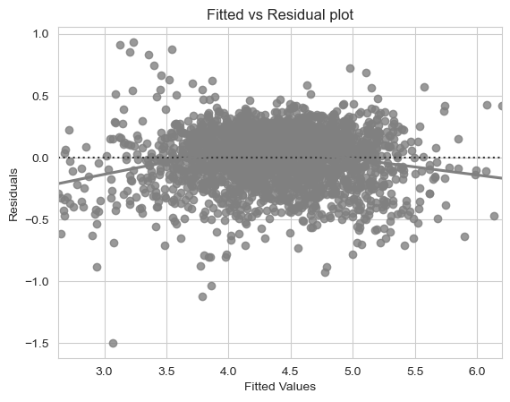

```python
# Plotting the fitted values vs residuals
sns.set_style("whitegrid")
sns.residplot(
    data=df_pred, x="Fitted Values", y="Residuals", color="gray", lowess=True
)

plt.xlabel("Fitted Values")
plt.ylabel("Residuals")
plt.title("Fitted vs Residual plot")
plt.show()
```

- The plots look random and one residual does not seem to affect the position of the other residual
- Therefore we can say the model fulfils the **linear and independent** assumptions

### Test for Normality

- Error terms/residuals should be normally distributed.

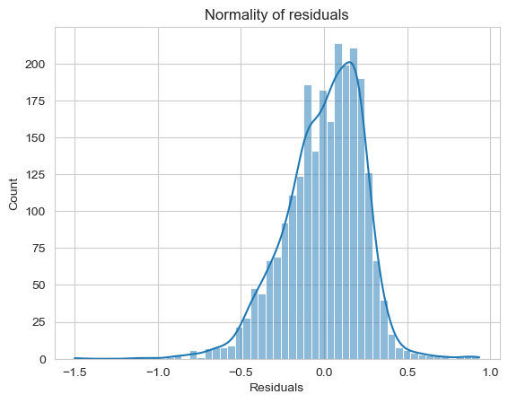

```python
# Constructing a Histogram of Residuals
sns.histplot(df_pred["Residuals"], kde=True)
plt.title("Normality of residuals")
plt.show()
```

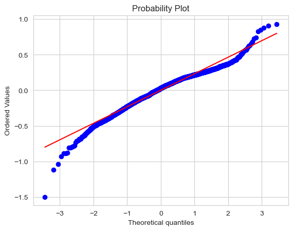

```python
# Creating a Q-Q Plot
import pylab
import scipy.stats as stats

stats.probplot(df_pred["Residuals"], dist="norm", plot=pylab)
plt.show()
```

Using the Shapiro-Wilk test to check for normality. The null and alternate hypotheses of the test are as follows:

- Null hypothesis - Data is normally distributed.
- Alternate hypothesis - Data is not normally distributed.

```python
# Conducting the Shapiro-Wilk test
stats.shapiro(df_pred["Residuals"])
```

```
ShapiroResult(statistic=0.9719365835189819, pvalue=2.305325709997579e-21)
```

- While statistically, the test indicates that the data is not normally distributed, statistical tests are often highly scrutenizing and by referring to the plots above, we can see that most points follow a normal distribution, lying within the Q-Q line
- Therefore we can still safely assume that our model's residuals follow a (relatively) normal distribution

### Test for Homoscedasticity

- If the variance of the residuals are symmetrically distributed across the regression line , then the data is said to homoscedastic.
- We can test for homoscedasticity by using the goldfeldquandt test

The null and alternate hypotheses of the goldfeldquandt test are as follows:

- Null hypothesis : Residuals are homoscedastic
- Alternate hypothesis : Residuals have hetroscedasticity

```python
import statsmodels.stats.api as sms
from statsmodels.compat import lzip
```

```python
name = ["F statistic", "p-value"]
test = sms.het_goldfeldquandt(df_pred["Residuals"], X_train5)
lzip(name, test)
```

```
[('F statistic', 1.060699691942269), ('p-value', 0.15371851296542877)]
```

- Since p-value > 0.05 we can say that the residuals are homoscedastic.

## Final Model

- As all assumptions of linear regresion are satisfied, we can view our model

```python
print(olsres10.summary())
```

```
                              OLS Regression Results
=================================================================================
Dep. Variable:     normalized_used_price   R-squared:                       0.837
Model:                               OLS   Adj. R-squared:                  0.837
Method:                    Least Squares   F-statistic:                     1771.
Date:                   Sat, 03 Feb 2024   Prob (F-statistic):               0.00
Time:                           04:02:49   Log-Likelihood:                 66.389
No. Observations:                   2417   AIC:                            -116.8
Df Residuals:                       2409   BIC:                            -70.46
Df Model:                              7
Covariance Type:               nonrobust
========================================================================================
                           coef    std err          t      P>|t|      [0.025      0.975]
----------------------------------------------------------------------------------------
const                  -51.1732      7.772     -6.584      0.000     -66.414     -35.933
screen_size              0.0428      0.001     28.641      0.000       0.040       0.046
main_camera_mp           0.0192      0.001     15.265      0.000       0.017       0.022
selfie_camera_mp         0.0133      0.001     12.479      0.000       0.011       0.015
ram                      0.0182      0.004      4.200      0.000       0.010       0.027
release_year             0.0259      0.004      6.741      0.000       0.018       0.033
days_used             6.142e-05   3.03e-05      2.024      0.043    1.91e-06       0.000
normalized_new_price     0.4312      0.010     41.086      0.000       0.411       0.452
==============================================================================
Omnibus:                      211.744   Durbin-Watson:                   1.913
Prob(Omnibus):                  0.000   Jarque-Bera (JB):              387.808
Skew:                          -0.602   Prob(JB):                     6.14e-85
Kurtosis:                       4.549   Cond. No.                     3.45e+06
==============================================================================

Notes:
[1] Standard Errors assume that the covariance matrix of the errors is correctly specified.
[2] The condition number is large, 3.45e+06. This might indicate that there are
strong multicollinearity or other numerical problems.
```

### Observations

- R-squared and Adjusted R-squared of the model is 0.837, which shows that the model is able to explain ~84% variance in the data, which is satisfactory
- A unit increase in the normalized new price will result in a 0.4312 unit increase in the normalized used price provided all other variables remaining constant.
- The main camera resolution has a 44% greater influence on the price as compared to the selfie camera resolution
- Other variables also contribute to the used price, specifically screen size (in cm) and release year whose unit increase accounts for 0.0428 and 0.0259 of the normalized used selling price respectively

## Actionable Insights and Recommendations

#### The main predictors for the selling price of a used phone are:

- The original asking price for the phone when it was new (the most significant predictor variable for selling price by far)
- The screen size
- Camera resolutions for both front and back facing cameras
- The year in which the phone or tablet was released
- Surprisingly, the brand of the phone/tablet or even the operating system had minimal correlation over the used selling price
- The battery and weight of the phone also do not have much influence over the used selling price (however this can also be due to multicollinearity between battery capacity, weight and screen size)

#### Recommendations:

- It is highly recommended to categorize whether the device is a phone or a tablet to better see which properties are more desirable in each device (eg. a larger screen size maybe more valuable for a tablet than a phone), this can lead to more accurate models and better insights on what influences the used selling price
- Basing the used price mainly around the original sticker price is a sound estimation to make when initially pricing the phone
- Focusing on refurbishing screens and cameras can be a good idea as the consumer puts more value on that than internal performance such as battery capacity and internal storage